# add challenge

# Display Advertising Challenge

(https://www.kaggle.com/c/criteo-display-ad-challenge/data)

The data was no longer available at the speciefied link

I was able to find it from Criteo. (http://labs.criteo.com/2014/02/kaggle-display-advertising-challenge-dataset/)

I suspect it is not the exact data set used for the challenge because of the number, oder, name of the variables. It consists of more than 46M rows. I used random sampling to obtain 300000 rows of data. /with respect to my available resources/

About the data Data fields Label - Target variable that indicates if an ad was clicked (1) or not (0). I1-I13 - A total of 13 columns of integer features (mostly count features). C1-C26 - A total of 26 columns of categorical features. The values of these features have been hashed onto 32 bits for anonymization purposes. The semantic of the features is undisclosed.

When a value is missing, the field is empty.

Until I know more about how to deal with the hashed values I would leave them out from the analysis. /“Hash functions may output the same value for different inputs” - To me that doesn’t speak accuracy in the calculations. But as I said. I will pay attention to that later.

I plan to use Logistic regression for this task.

```r
library(readr)
# load data
train300 <- read_csv("C://Users/Public/Documents/Tiharis R/train300.csv", col_names = FALSE)[,1:13]


for (i in c(2:ncol(train300))) {
      train300[,i] <- as.numeric(as.integer(as.character(unlist(train300[,i]))))
}

# Removing allegedly a categorical variable that left.
train300$X10 <- NULL

# train300$X1 <- as.factor(train300$X1)
```

# EDA

```r
summary(train300)
```

```
##        X1               X2                 X3                 X4
##  Min.   :0.0000   Min.   :   -2.00   Min.   :      -2   Min.   :       0
##  1st Qu.:0.0000   1st Qu.:    0.00   1st Qu.:       1   1st Qu.:       2
##  Median :0.0000   Median :    1.00   Median :       5   Median :       6
##  Mean   :0.2561   Mean   :   44.82   Mean   :    3867   Mean   :    8550
##  3rd Qu.:1.0000   3rd Qu.:    7.00   3rd Qu.:      36   3rd Qu.:      27
##  Max.   :1.0000   Max.   :10469.00   Max.   :87552397   Max.   :87552397
##                                      NA's   :145        NA's   :984
##        X5                 X6                  X7
##  Min.   :       0   Min.   :        0   Min.   :       0
##  1st Qu.:       3   1st Qu.:        2   1st Qu.:       2
##  Median :      14   Median :       26   Median :       8
##  Mean   :   27224   Mean   :    22350   Mean   :   24135
##  3rd Qu.:    2839   3rd Qu.:      391   3rd Qu.:      30
##  Max.   :98237733   Max.   :511156000   Max.   :98237733
##  NA's   :3884       NA's   :6391        NA's   :8526
##        X8                  X9                 X11
##  Min.   :        0   Min.   :        0   Min.   :        0
##  1st Qu.:        2   1st Qu.:        1   1st Qu.:        0
##  Median :        7   Median :       10   Median :        1
##  Mean   :    76526   Mean   :   133534   Mean   :   495323
##  3rd Qu.:       22   3rd Qu.:       33   3rd Qu.:        2
##  Max.   :511156000   Max.   :961290000   Max.   :511156000
##  NA's   :17255       NA's   :32082       NA's   :94325
##       X12                 X13
##  Min.   :        0   Min.   :        0
##  1st Qu.:        1   1st Qu.:        0
##  Median :        2   Median :        3
##  Mean   :   820474   Mean   :   865780
##  3rd Qu.:        5   3rd Qu.:        9
##  Max.   :705740000   Max.   :511156000
##  NA's   :144992      NA's   :172115
```

From the summary I see that all the variables are heavily skewed to the right. Mean, Median difference is huge. I see many missing values, so I’ll plot them to see whether there is a pattern or something that might speak up. The data resides above the 3rd quartile meaning that 75% of the data is less than the number corespoding to the 3rd quartile. In context of the variable I can’t speak, so I can’t take any well-argumented decisions. I may treat these extreme high data points as are or bin the variable. I also think about the NA’s - for some variables missing values may make sense. For that they should be treated accordingly. We’ll see. What I also notice is the same extreme value ‘511156000’ in variables X6, X8, X11 and X13. The same is with X3 and X4 ‘87552397’ and X5 and X7 ‘98237733’. There is a class bias for the response varbiable X1. I may sample more balanced data for the model but we’ll see.

```r
# I will get in numerical form the skewness and the kurtosis
library(psych)
describe(train300)
```

```
##     vars      n      mean         sd median trimmed   mad min       max
## X1     1 300000      0.26       0.44      0    0.20  0.00   0         1
## X2     2 300000     44.82     244.52      1    4.52  1.48  -2     10469
## X3     3 299855   3867.12  278537.78      5   28.36  7.41  -2  87552397
## X4     4 299016   8549.67  621113.54      6   59.24  7.41   0  87552397
## X5     5 296116  27223.75 1205105.10     14 1580.13 20.76   0  98237733
## X6     6 293609  22350.18 1591223.37     26  272.60 38.55   0 511156000
## X7     7 291474  24135.33 1373172.85      8   16.37 10.38   0  98237733
## X8     8 282745  76526.25 2609410.78      7   12.22  8.90   0 511156000
## X9     9 267918 133533.54 3746332.25     10   16.75 14.83   0 961290000
## X11   10 205675 495323.35 6383570.38      1    1.25  1.48   0 511156000
## X12   11 155008 820474.47 8458144.95      2    3.19  1.48   0 705740000
## X13   12 127885 865779.51 8096012.92      3    4.93  4.45   0 511156000
##         range   skew kurtosis       se
## X1          1   1.12    -0.75     0.00
## X2      10471   9.88   124.17     0.45
## X3   87552399 310.70 97646.35   508.66
## X4   87552397 140.47 19794.77  1135.86
## X5   98237733  71.95  5220.82  2214.59
## X6  511156000 148.07 38186.34  2936.61
## X7   98237733  61.02  3819.79  2543.46
## X8  511156000  54.38  6118.15  4907.33
## X9  961290000  80.19 16565.39  7237.78
## X11 511156000  15.58   386.37 14075.79
## X12 705740000  19.63   960.43 21483.16
## X13 511156000  14.76   460.31 22639.22
```

I plan to log transform the data in order to reduce the skew. Too much skewness will mess up the statistical techinques.

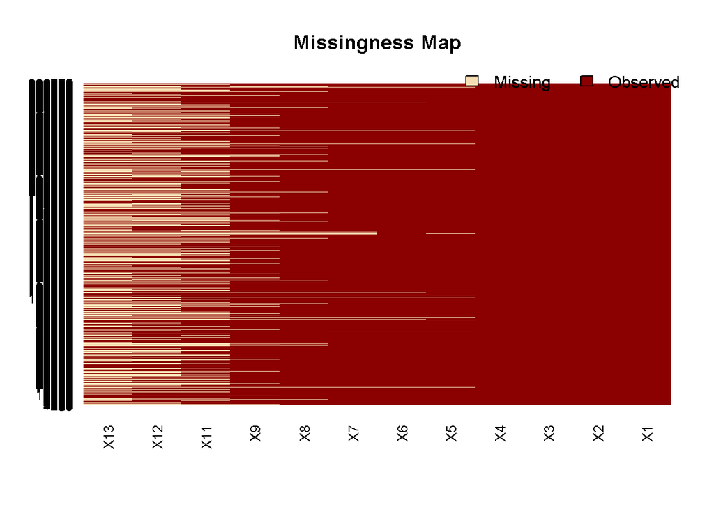

```r
library(Amelia)
# plot NA's
missmap(train300)
```

```r
# missing values in percentage
round(sapply(train300, function(x) sum(length(which(is.na(x))))) / nrow(train300),3)*100
```

```
##   X1   X2   X3   X4   X5   X6   X7   X8   X9  X11  X12  X13
##  0.0  0.0  0.0  0.3  1.3  2.1  2.8  5.8 10.7 31.4 48.3 57.4
```

After seeing the missing NA’s plot I decide to remove my attention from the variables X12 and X13. Imputing any numbers would lead to creating data insead of invastigating it. I see monotone missing data pattern - when a value is missing in a column it continuos to be missing in the next column. That might be a bit misleading because of the condensed plot. Probably X11 will go away as well but first I will investigate it further. The imputation I’m considering is k-NN /k nearest neighbor/.But we’ll see.

```r
# Copy data
train300_copy <-  train300
```

# Histograms

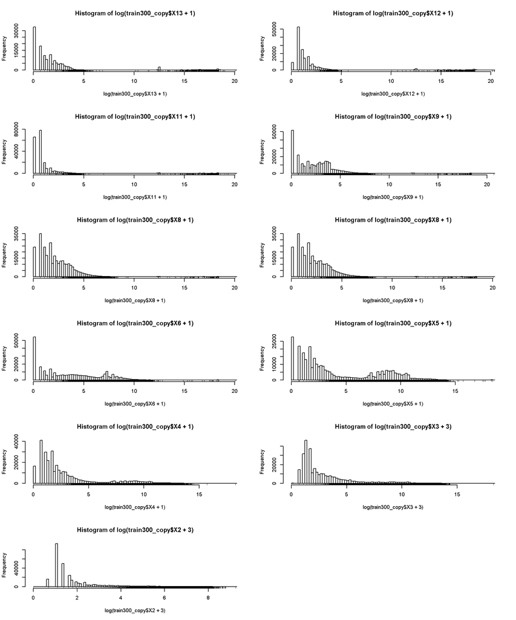

```r
par(mfrow = c(6, 2))
par(cex = 0.6)
# I will do log transformation of the variables in order to see their distribution a little bit better.
hist(log(train300_copy$X13+1),breaks=80)
rug(jitter(log(train300_copy$X13+1)))
hist(log(train300_copy$X12+1),breaks=80)
rug(jitter(log(train300_copy$X12+1)))
hist(log(train300_copy$X11+1),breaks=80)
rug(jitter(log(train300_copy$X11+1)))
hist(log(train300_copy$X9+1),breaks=80)
rug(jitter(log(train300_copy$X9+1)))
hist(log(train300_copy$X8+1),breaks=80)
rug(jitter(log(train300_copy$X8+1)))
hist(log(train300_copy$X8+1),breaks=80)
rug(jitter(log(train300_copy$X8+1)))
hist(log(train300_copy$X6+1),breaks=80)
rug(jitter(log(train300_copy$X6+1)))
hist(log(train300_copy$X5+1),breaks=80)
rug(jitter(log(train300_copy$X5+1)))
hist(log(train300_copy$X4+1),breaks=80)
rug(jitter(log(train300_copy$X4+1)))
hist(log(train300_copy$X3+3),breaks=80)
rug(jitter(log(train300_copy$X3+1)))
hist(log(train300_copy$X2+3),breaks=80)
rug(jitter(log(train300_copy$X2+3)))
```

# Boxplots

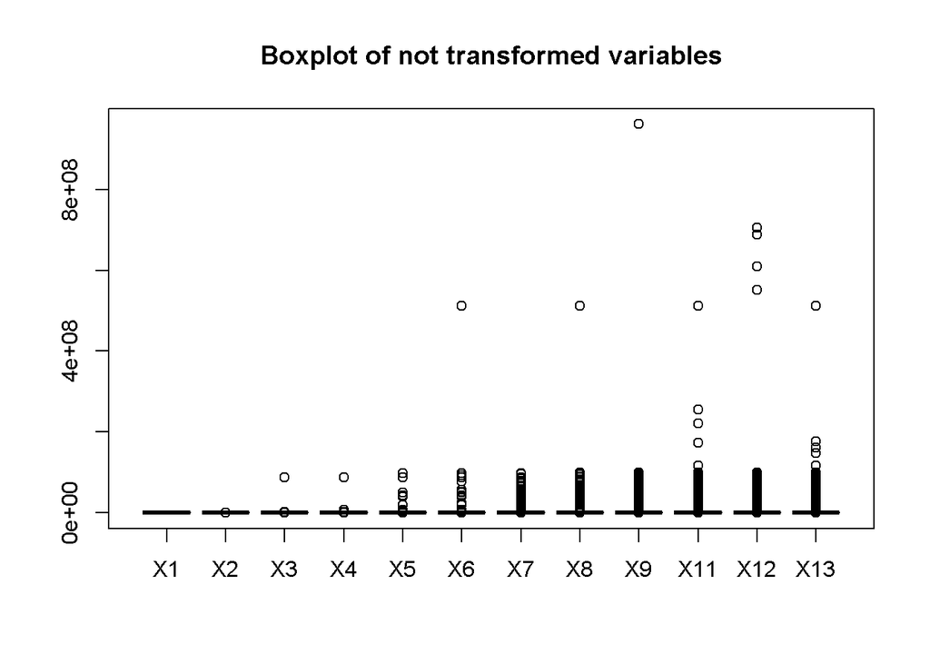

```r
# yet another way of seeing the distribution and the variability of the variables
boxplot(train300, main = "Boxplot of not transformed variables")
```

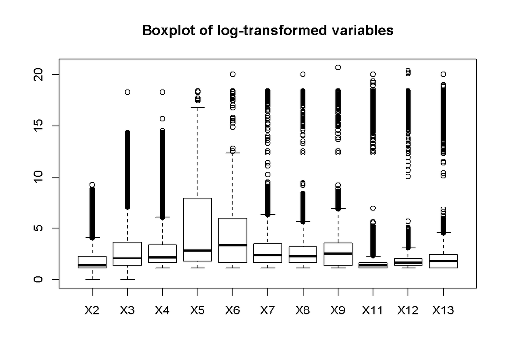

```r
boxplot(log(train300[,-1]+3),main = "Boxplot of log-transformed variables")
```

Schould I treat the extreme observations as outliers or not? They represent 25% of the data. That perhaps shouldn’t be ignored.

```r
# Removing the last 3 variables from the analysis because of too much missing data
train300_copy$X13 <- NULL
train300_copy$X12 <- NULL
train300_copy$X11 <- NULL
```

```r
# Find the mode for every variable
MODE <- function(dataframe){
            DF <- as.data.frame(dataframe)

            MODE2 <- function(x){
                  if (is.numeric(x) == FALSE){
                        df <- as.data.frame(table(x))
                        df <- df[order(df$Freq), ]
                        m <- max(df$Freq)
                        MODE1 <- as.vector(as.character(subset(df, Freq == m)[, 1]))

                        if (sum(df$Freq)/length(df$Freq)==1){
                              warning("No Mode: Frequency of all values is 1", call. = FALSE)
                        }else{
                              return(MODE1)
                        }

                  }else{
                        df <- as.data.frame(table(x))
                        df <- df[order(df$Freq), ]
                        m <- max(df$Freq)
                        MODE1 <- as.vector(as.numeric(as.character(subset(df, Freq == m)[, 1])))

                        if (sum(df$Freq)/length(df$Freq)==1){
                              warning("No Mode: Frequency of all values is 1", call. = FALSE)
                        }else{
                              return(MODE1)
                        }
                  }
            }

            return(as.vector(lapply(DF, MODE2)))
      }
# Display the mode of every variable
as.data.frame(MODE(train300_copy))
```

```
##   X1 X2 X3 X4 X5 X6 X7 X8 X9
## 1  0  0  1  1  0  0  0  1  0
```

I am considering an option to separate the variables at their mode and thus making them categorical ones. I can’t yet decide whether to do it with 2 levels or 3 or 4.. or leave them as they are

```r
# How many missing values for each variable
sapply(train300_copy,function(x) sum(is.na(x)))
```

```
##    X1    X2    X3    X4    X5    X6    X7    X8    X9
##     0     0   145   984  3884  6391  8526 17255 32082
```

```r
# how many unique values for each variable
sapply(train300_copy, function(x) length(unique(x)))
```

```
##    X1    X2    X3    X4    X5    X6    X7    X8    X9
##     2  2850 16042 19127 32116 11580  1892  1296  1510
```

I’ll keep those variables in mind.  
# Imputation I may also try the default setting for the number of multiple imputations `m`, which is 5.  
`maxit` - the number of iterations which is again 5. But for large sample size 10 and up may give better results. I will do it for now with low settings

```r
# Imputing data with predictive mean matching
library(mice)
imputedData300 <- mice(train300_copy, m=2, maxit = 5, method = 'pmm', seed = 500)
# I will chose the second dataset and combine it with the original data
train300_copy_imputed <- complete(imputedData300, 2)
# Check for NA's
anyNA(train300_copy_imputed)
```

```
## [1] FALSE
```

```r
# Compare summary statistics
summary(train300_copy)
```

```
##        X1               X2                 X3                 X4
##  Min.   :0.0000   Min.   :   -2.00   Min.   :      -2   Min.   :       0
##  1st Qu.:0.0000   1st Qu.:    0.00   1st Qu.:       1   1st Qu.:       2
##  Median :0.0000   Median :    1.00   Median :       5   Median :       6
##  Mean   :0.2561   Mean   :   44.82   Mean   :    3867   Mean   :    8550
##  3rd Qu.:1.0000   3rd Qu.:    7.00   3rd Qu.:      36   3rd Qu.:      27
##  Max.   :1.0000   Max.   :10469.00   Max.   :87552397   Max.   :87552397
##                                      NA's   :145        NA's   :984
##        X5                 X6                  X7
##  Min.   :       0   Min.   :        0   Min.   :       0
##  1st Qu.:       3   1st Qu.:        2   1st Qu.:       2
##  Median :      14   Median :       26   Median :       8
##  Mean   :   27224   Mean   :    22350   Mean   :   24135
##  3rd Qu.:    2839   3rd Qu.:      391   3rd Qu.:      30
##  Max.   :98237733   Max.   :511156000   Max.   :98237733
##  NA's   :3884       NA's   :6391        NA's   :8526
##        X8                  X9
##  Min.   :        0   Min.   :        0
##  1st Qu.:        2   1st Qu.:        1
##  Median :        7   Median :       10
##  Mean   :    76526   Mean   :   133534
##  3rd Qu.:       22   3rd Qu.:       33
##  Max.   :511156000   Max.   :961290000
##  NA's   :17255       NA's   :32082
```

```r
summary(train300_copy_imputed)
```

```
##        X1               X2                 X3                 X4
##  Min.   :0.0000   Min.   :   -2.00   Min.   :      -2   Min.   :       0
##  1st Qu.:0.0000   1st Qu.:    0.00   1st Qu.:       1   1st Qu.:       2
##  Median :0.0000   Median :    1.00   Median :       5   Median :       6
##  Mean   :0.2561   Mean   :   44.82   Mean   :    3869   Mean   :    8842
##  3rd Qu.:1.0000   3rd Qu.:    7.00   3rd Qu.:      36   3rd Qu.:      27
##  Max.   :1.0000   Max.   :10469.00   Max.   :87552397   Max.   :87552397
##        X5                 X6                  X7
##  Min.   :       0   Min.   :        0   Min.   :       0
##  1st Qu.:       3   1st Qu.:        2   1st Qu.:       2
##  Median :      14   Median :       25   Median :       8
##  Mean   :   33876   Mean   :    50121   Mean   :   61858
##  3rd Qu.:    2789   3rd Qu.:      367   3rd Qu.:      30
##  Max.   :98237733   Max.   :511156000   Max.   :98237733
##        X8                  X9
##  Min.   :        0   Min.   :        0
##  1st Qu.:        2   1st Qu.:        1
##  Median :        7   Median :        9
##  Mean   :   268595   Mean   :   476578
##  3rd Qu.:       22   3rd Qu.:       32
##  Max.   :511156000   Max.   :961290000
```

The summary comparison reveals to what extent I influenced the variables. Some of them remain solid, some are influenced a bit, In my oppinion it is quite survivable. I plan to use both imputed data sets to compare their performance. # Log transform

```r
# Copy the imputed data
train300_copy_imputed_log <- train300_copy_imputed
# Transform every variable but the response variable
train300_copy_imputed_log[,-1] <- log(train300_copy_imputed_log[, -1] + 3)
summary(train300_copy_imputed_log)
```

```
##        X1               X2              X3               X4
##  Min.   :0.0000   Min.   :0.000   Min.   : 0.000   Min.   : 1.099
##  1st Qu.:0.0000   1st Qu.:1.099   1st Qu.: 1.386   1st Qu.: 1.609
##  Median :0.0000   Median :1.386   Median : 2.079   Median : 2.197
##  Mean   :0.2561   Mean   :1.978   Mean   : 2.965   Mean   : 3.170
##  3rd Qu.:1.0000   3rd Qu.:2.303   3rd Qu.: 3.664   3rd Qu.: 3.401
##  Max.   :1.0000   Max.   :9.256   Max.   :18.288   Max.   :18.288
##        X5               X6               X7               X8
##  Min.   : 1.099   Min.   : 1.099   Min.   : 1.099   Min.   : 1.099
##  1st Qu.: 1.792   1st Qu.: 1.609   1st Qu.: 1.609   1st Qu.: 1.609
##  Median : 2.833   Median : 3.332   Median : 2.398   Median : 2.303
##  Mean   : 4.493   Mean   : 3.923   Mean   : 2.694   Mean   : 2.587
##  3rd Qu.: 7.935   3rd Qu.: 5.914   3rd Qu.: 3.497   3rd Qu.: 3.219
##  Max.   :18.403   Max.   :20.052   Max.   :18.403   Max.   :20.052
##        X9
##  Min.   : 1.099
##  1st Qu.: 1.386
##  Median : 2.485
##  Mean   : 2.762
##  3rd Qu.: 3.555
##  Max.   :20.684
```

```r
# Change names accordingly
names(train300_copy_imputed_log) <- paste0(names(train300_copy_imputed_log), "_log")
names(train300_copy_imputed_log)[names(train300_copy_imputed_log) == "X1_log"] <- "X1"
```

# Split data

I will randomly reorder the data and then split it into train and test sets.

```r
# Shuffle rows
shuf <- sample(nrow(train300_copy_imputed_log))
# Randomly order data
train300_copy_imputed_log <- train300_copy_imputed_log[shuf,]
# Identify row to split on
split <- round(nrow(train300_copy_imputed_log) * .80)
# Create train
train_train300_copy_imputed_log <- train300_copy_imputed_log[1:split,]
# Create test
test_train300_copy_imputed_log <- train300_copy_imputed_log[(split + 1):nrow(train300_copy_imputed_log), ]
# check splitting
nrow(train_train300_copy_imputed_log)/nrow(train300_copy_imputed_log)
```

```
## [1] 0.8
```

```r
str(train_train300_copy_imputed_log)
```

```
## 'data.frame':    240000 obs. of  9 variables:
##  $ X1    : int  1 1 0 0 1 0 0 0 1 0 ...
##  $ X2_log: num  2.56 1.95 1.39 3.89 1.1 ...
##  $ X3_log: num  4.17 2.48 8.41 2.94 3.26 ...
##  $ X4_log: num  1.79 2.4 1.1 7.6 1.39 ...
##  $ X5_log: num  2.4 8.3 1.1 3.64 1.39 ...
##  $ X6_log: num  6.3 5.24 3 2.3 7.81 ...
##  $ X7_log: num  2.4 3.43 1.1 3.53 2.71 ...
##  $ X8_log: num  4.64 3.3 1.95 3.64 2.3 ...
##  $ X9_log: num  2.94 5.67 1.39 1.39 1.39 ...
```

# Model building

```r
# 1 glm model
LogModel1 <- glm(X1 ~ ., data = train_train300_copy_imputed_log, family = binomial)
summary(LogModel1)
```

```
##
## Call:
## glm(formula = X1 ~ ., family = binomial, data = train_train300_copy_imputed_log)
##
## Deviance Residuals:
##     Min       1Q   Median       3Q      Max
## -1.5427  -0.7853  -0.6694   1.2642   3.4178
##
## Coefficients:
##              Estimate Std. Error z value Pr(>|z|)
## (Intercept)  0.327849   0.022618  14.495  < 2e-16 ***
## X2_log      -0.001664   0.003773  -0.441    0.659
## X3_log      -0.034692   0.002132 -16.275  < 2e-16 ***
## X4_log      -0.081383   0.002117 -38.444  < 2e-16 ***
## X5_log      -0.128464   0.001655 -77.633  < 2e-16 ***
## X6_log      -0.082325   0.002306 -35.708  < 2e-16 ***
## X7_log      -0.126601   0.004067 -31.130  < 2e-16 ***
## X8_log       0.053021   0.003028  17.511  < 2e-16 ***
## X9_log       0.011844   0.002441   4.852 1.22e-06 ***
## ---
## Signif. codes:  0 '***' 0.001 '**' 0.01 '*' 0.05 '.' 0.1 ' ' 1
##
## (Dispersion parameter for binomial family taken to be 1)
##
##     Null deviance: 273276  on 239999  degrees of freedom
## Residual deviance: 264812  on 239991  degrees of freedom
## AIC: 264830
##
## Number of Fisher Scoring iterations: 4
```

```r
# 2 glm model
LogModel2 <- glm(X1 ~ . - X2_log, data = train_train300_copy_imputed_log, family = binomial)
summary(LogModel2)
```

```
##
## Call:
## glm(formula = X1 ~ . - X2_log, family = binomial, data = train_train300_copy_imputed_log)
##
## Deviance Residuals:
##     Min       1Q   Median       3Q      Max
## -1.5420  -0.7853  -0.6694   1.2641   3.4171
##
## Coefficients:
##              Estimate Std. Error z value Pr(>|z|)
## (Intercept)  0.324051   0.020914  15.495  < 2e-16 ***
## X3_log      -0.034643   0.002129 -16.274  < 2e-16 ***
## X4_log      -0.081385   0.002117 -38.447  < 2e-16 ***
## X5_log      -0.128535   0.001647 -78.043  < 2e-16 ***
## X6_log      -0.082155   0.002273 -36.145  < 2e-16 ***
## X7_log      -0.126508   0.004061 -31.150  < 2e-16 ***
## X8_log       0.052958   0.003024  17.511  < 2e-16 ***
## X9_log       0.011821   0.002440   4.844 1.27e-06 ***
## ---
## Signif. codes:  0 '***' 0.001 '**' 0.01 '*' 0.05 '.' 0.1 ' ' 1
##
## (Dispersion parameter for binomial family taken to be 1)
##
##     Null deviance: 273276  on 239999  degrees of freedom
## Residual deviance: 264812  on 239992  degrees of freedom
## AIC: 264828
##
## Number of Fisher Scoring iterations: 4
```

```r
# 3 glm model /whitout the near zero variance variables one at a time/
LogModel3 <- glm(X1 ~ . - X2_log - X9_log, data = train_train300_copy_imputed_log, family = binomial)
summary(LogModel3)
```

```
##
## Call:
## glm(formula = X1 ~ . - X2_log - X9_log, family = binomial, data = train_train300_copy_imputed_log)
##
## Deviance Residuals:
##     Min       1Q   Median       3Q      Max
## -1.5045  -0.7857  -0.6698   1.2631   3.4348
##
## Coefficients:
##              Estimate Std. Error z value Pr(>|z|)
## (Intercept)  0.333534   0.020831   16.01   <2e-16 ***
## X3_log      -0.032616   0.002085  -15.64   <2e-16 ***
## X4_log      -0.082059   0.002113  -38.84   <2e-16 ***
## X5_log      -0.127765   0.001639  -77.94   <2e-16 ***
## X6_log      -0.080386   0.002244  -35.83   <2e-16 ***
## X7_log      -0.125820   0.004064  -30.96   <2e-16 ***
## X8_log       0.055640   0.002972   18.72   <2e-16 ***
## ---
## Signif. codes:  0 '***' 0.001 '**' 0.01 '*' 0.05 '.' 0.1 ' ' 1
##
## (Dispersion parameter for binomial family taken to be 1)
##
##     Null deviance: 273276  on 239999  degrees of freedom
## Residual deviance: 264836  on 239993  degrees of freedom
## AIC: 264850
##
## Number of Fisher Scoring iterations: 4
```

```r
# 4 glm model /whitout the near zero variance variables one at a time/
LogModel4 <- glm(X1 ~ . - X2_log - X9_log -X6_log, data = train_train300_copy_imputed_log, family = binomial)
summary(LogModel4)
```

```
##
## Call:
## glm(formula = X1 ~ . - X2_log - X9_log - X6_log, family = binomial,
##     data = train_train300_copy_imputed_log)
##
## Deviance Residuals:
##     Min       1Q   Median       3Q      Max
## -1.4255  -0.7941  -0.6768   1.3276   3.3884
##
## Coefficients:
##              Estimate Std. Error z value Pr(>|z|)
## (Intercept)  0.027749   0.019232   1.443    0.149
## X3_log      -0.016831   0.002052  -8.202 2.36e-16 ***
## X4_log      -0.059662   0.002027 -29.434  < 2e-16 ***
## X5_log      -0.115618   0.001599 -72.290  < 2e-16 ***
## X7_log      -0.188458   0.003732 -50.500  < 2e-16 ***
## X8_log       0.052585   0.002991  17.578  < 2e-16 ***
## ---
## Signif. codes:  0 '***' 0.001 '**' 0.01 '*' 0.05 '.' 0.1 ' ' 1
##
## (Dispersion parameter for binomial family taken to be 1)
##
##     Null deviance: 273276  on 239999  degrees of freedom
## Residual deviance: 266132  on 239994  degrees of freedom
## AIC: 266144
##
## Number of Fisher Scoring iterations: 4
```

The interpretation of the coefficients will be a challenge for me, because the glm model gives the coefficients in the log odds scale and I already took the natural log of them.but I’ll give it a try. For variables X3_log to X7_log I see decrease from The log odds ratio associated with a 2.72 fold change in the predictor. By just looking at the sign of the estimates I may say that which one has positive or negative affect on the response variable X1 which represents whether the add was clicked on or not. I will show the LogModel2 in odds scale for hopefully easier interpretation. For variables X3_log to X7_log I see assosiated decrease in the odds of Click. for example: X3_log would be interpreted as: each additional log unit of variable X3_log is assosiated with 3.4% decrease in the odds of Click. The difference between the null deviance and the residual deviance is not big. It would mean/when there is a bigger gap/ that variables add value to the model.

```r
# Coefficients and their CI of LogModel2 in the ddds scale
exp(cbind(Odds = coef(LogModel2), confint(LogModel2)))
```

```
##                  Odds     2.5 %    97.5 %
## (Intercept) 1.3827174 1.3271997 1.4405878
## X3_log      0.9659497 0.9619244 0.9699851
## X4_log      0.9218387 0.9180171 0.9256664
## X5_log      0.8793826 0.8765459 0.8822232
## X6_log      0.9211291 0.9170334 0.9252405
## X7_log      0.8811671 0.8741696 0.8881977
## X8_log      1.0543851 1.0481535 1.0606541
## X9_log      1.0118908 1.0070520 1.0167324
```

Here I see that no coefficients in the odds scale crosses zero which indicates to me that all of the variables have to some extent, even small one/ influence one the response variable. Apart from X8_log and X9_log that have a tiny positive influence all other remaining variables have a negative one.  
# AIC comparison Comparing models by their Akaike Information Criterion - evaluating the quality of the model

```r
# AIC comparison
AIC(LogModel1,LogModel2,LogModel3,LogModel4)
```

```
##           df      AIC
## LogModel1  9 264830.2
## LogModel2  8 264828.4
## LogModel3  7 264849.6
## LogModel4  6 266143.5
```

Model 2 is better. I will continue with it.

# Predictions

```r
# prediction
p <- predict(LogModel2, test_train300_copy_imputed_log, type = "response")
# set prediction probability for the model
p_class <- ifelse(p > 0.2, 1, 0)
# create confusion matrix
table(predicted = p_class, actual = test_train300_copy_imputed_log$X1)
```

```
##          actual
## predicted     0     1
##         0 14366  2878
##         1 30362 12394
```

```r
# estimate the accuracy of the model
mean(p_class == test_train300_copy_imputed_log$X1)
```

```
## [1] 0.446
```

If I set the cutoff value to be 0.20 I would get more clicks but with less certanty than if I set it to 0.6.

```r
# set prediction probability for the model
p_class <- ifelse(p > 0.6, 1, 0)
# create confusion matrix
table(predicted = p_class, actual = test_train300_copy_imputed_log$X1)
```

```
##          actual
## predicted     0     1
##         0 44686 15268
##         1    42     4
```

```r
# estimate the accuracy of the model
mean(p_class == test_train300_copy_imputed_log$X1)
```

```
## [1] 0.7448333
```

# ROC curve and AUC

I will draw a ROC curve and see the possible cutoff point as welll as the overall performance of the model across these thresholds.

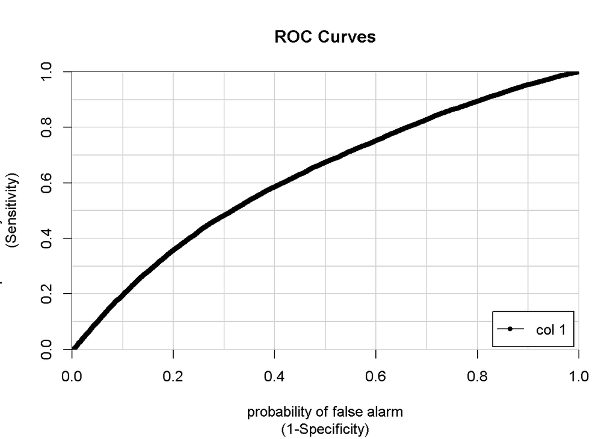

```
##              [,1]
## 0 vs. 1 0.6229923
```

```r
library(caTools)
# Draw a ROC curve
colAUC(p, test_train300_copy_imputed_log$X1, plotROC = T)
```

I would choose to set the threshold a bit over the average probability of success

```r
# Check once again the average prop of clicks
mean(test_train300_copy_imputed_log$X1)
```

```
## [1] 0.2545333
```

```r
# I decide to leave it at 0.26
p_class <- ifelse(p > 0.26, 1, 0)
# create confusion matrix
table(predicted = p_class, actual = test_train300_copy_imputed_log$X1)
```

```
##          actual
## predicted     0     1
##         0 28578  6922
##         1 16150  8350
```

```r
# estimate the accuracy of the model
mean(p_class == test_train300_copy_imputed_log$X1)
```

```
## [1] 0.6154667
```

# Performance

```r
sensitivity <-  8350 / (8350 + 16150 )
specificity <-  28578 / (28578 + 6922)
sensitivity
```

```
## [1] 0.3408163
```

```r
specificity
```

```
## [1] 0.8050141
```

```r
# McFadden R2 index can be used to assess the model fit
library(pscl)
pR2(LogModel2)
```

```
##           llh       llhNull            G2      McFadden          r2ML
## -1.324062e+05 -1.366378e+05  8.463247e+03  3.096964e-02  3.464901e-02
##          r2CU
##  5.097329e-02
```

Well, now I am confused. # Second imputed dataset model

```r
# GLM for both of the imputed data set
ModelIIset <- with(imputedData300, glm(X1 ~ ., data = train_train300_copy_imputed_log, family = binomial))
summary(ModelIIset)
```

```
##
##  ## summary of imputation 1 :
##
## Call:
## glm(formula = X1 ~ ., family = binomial, data = train_train300_copy_imputed_log)
##
## Deviance Residuals:
##     Min       1Q   Median       3Q      Max
## -1.5427  -0.7853  -0.6694   1.2642   3.4178
##
## Coefficients:
##              Estimate Std. Error z value Pr(>|z|)
## (Intercept)  0.327849   0.022618  14.495  < 2e-16 ***
## X2_log      -0.001664   0.003773  -0.441    0.659
## X3_log      -0.034692   0.002132 -16.275  < 2e-16 ***
## X4_log      -0.081383   0.002117 -38.444  < 2e-16 ***
## X5_log      -0.128464   0.001655 -77.633  < 2e-16 ***
## X6_log      -0.082325   0.002306 -35.708  < 2e-16 ***
## X7_log      -0.126601   0.004067 -31.130  < 2e-16 ***
## X8_log       0.053021   0.003028  17.511  < 2e-16 ***
## X9_log       0.011844   0.002441   4.852 1.22e-06 ***
## ---
## Signif. codes:  0 '***' 0.001 '**' 0.01 '*' 0.05 '.' 0.1 ' ' 1
##
## (Dispersion parameter for binomial family taken to be 1)
##
##     Null deviance: 273276  on 239999  degrees of freedom
## Residual deviance: 264812  on 239991  degrees of freedom
## AIC: 264830
##
## Number of Fisher Scoring iterations: 4
##
##
##  ## summary of imputation 2 :
##
## Call:
## glm(formula = X1 ~ ., family = binomial, data = train_train300_copy_imputed_log)
##
## Deviance Residuals:
##     Min       1Q   Median       3Q      Max
```

[output cut: 8 more lines]

```
## X5_log      -0.128464   0.001655 -77.633  < 2e-16 ***
## X6_log      -0.082325   0.002306 -35.708  < 2e-16 ***
## X7_log      -0.126601   0.004067 -31.130  < 2e-16 ***
## X8_log       0.053021   0.003028  17.511  < 2e-16 ***
## X9_log       0.011844   0.002441   4.852 1.22e-06 ***
## ---
## Signif. codes:  0 '***' 0.001 '**' 0.01 '*' 0.05 '.' 0.1 ' ' 1
##
## (Dispersion parameter for binomial family taken to be 1)
##
##     Null deviance: 273276  on 239999  degrees of freedom
## Residual deviance: 264812  on 239991  degrees of freedom
## AIC: 264830
##
## Number of Fisher Scoring iterations: 4
```

Both of the imputed datasets yield the same results in respect of the significance of the variables.

# Cor plot

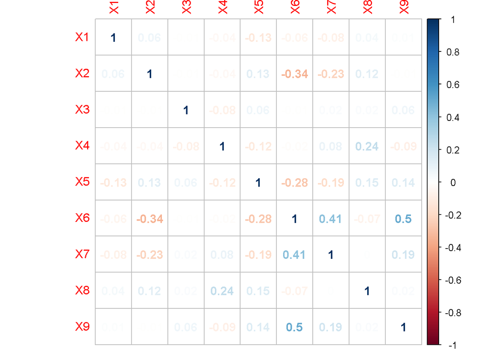

```r
# correlation
library(corrplot)
correlations_o <- round(cor(train300_copy, use = "complete.obs",method = "spearman"),2)
corrplot(correlations_o, method = "number")
```

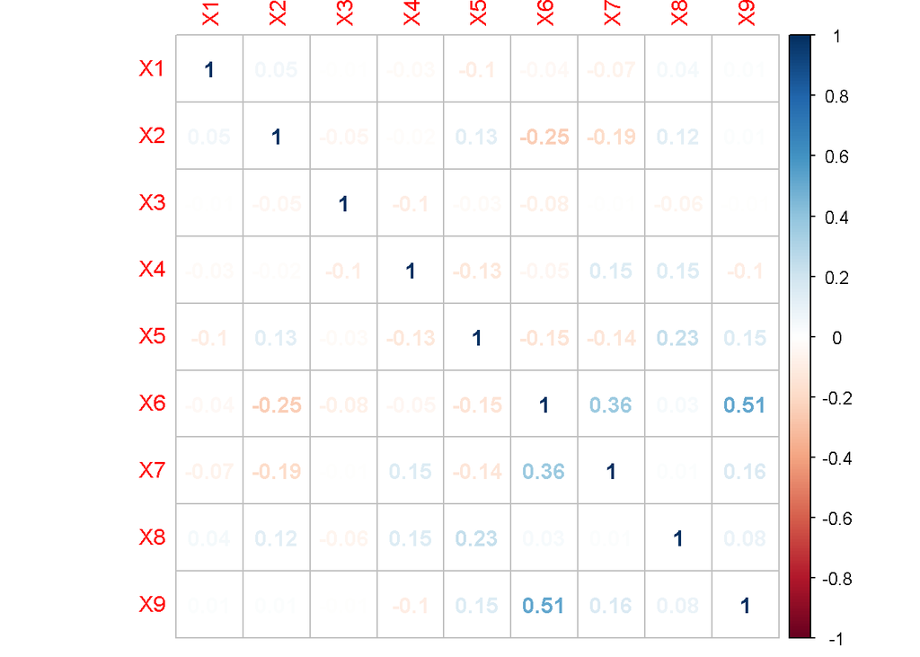

```r
correlations_i <- round(cor(train300_copy_imputed, method = "spearman"),2)
corrplot(correlations_i, method = "number")
```

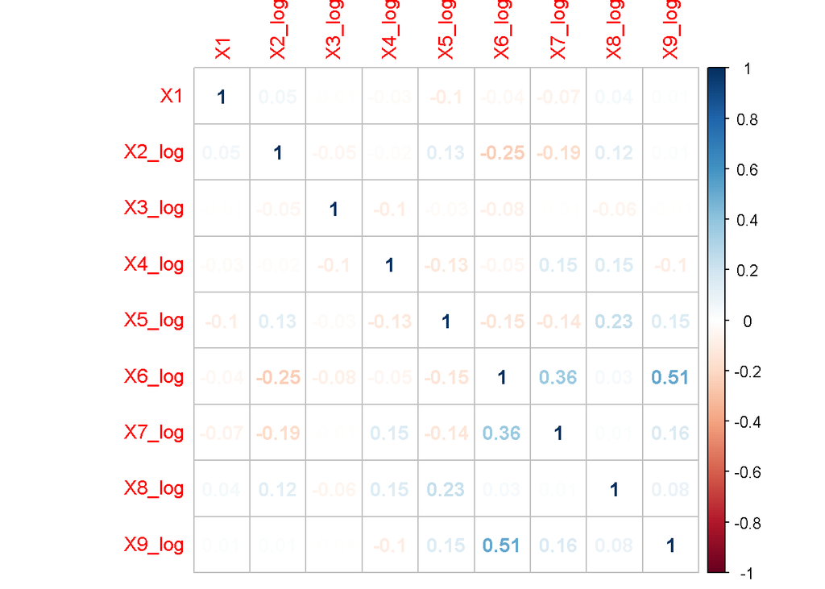

```r
correlations_il <- round(cor(log(train300_copy_imputed_log),method = "spearman"),2)
corrplot(correlations_il, method = "number")
```

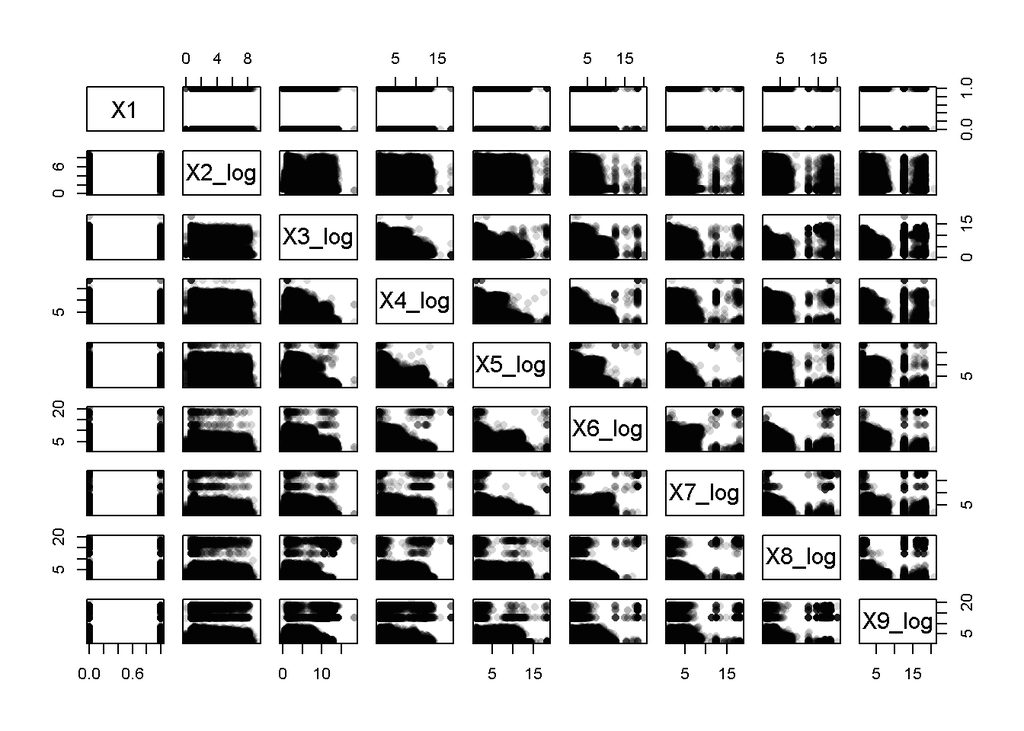

```r
pl <- plot(train300_copy_imputed_log, col=rgb(0,0,0,40,maxColorValue=255) , pch = 16)
```

```r
pl
```

# Caret package

I would like to train the model using the `caret` package as well.

```r
# Copy data
caret300 <- train300_copy
# Delete variables with many NA's
caret300$X13 <- NULL
caret300$X12 <- NULL
caret300$X11 <- NULL
# Rename response variable
names(caret300)[names(caret300) == 'X1'] <- 'Class'
# Make the response variabel a factor
caret300$Class <- as.factor(caret300$Class)
# Renane
library(plyr)
caret300$Class <- mapvalues(caret300$Class, from = c("0", "1"), to = c("N", "C"))
# Create more balanced data in order the model to learn better.
library(dplyr)
caret300_b <- caret300 %>%
              group_by(Class) %>%
              sample_n(75000)

caret300_b[,-1] <- log(caret300_b[,-1] + 3)

str(caret300_b)
```

```
## Classes 'grouped_df', 'tbl_df', 'tbl' and 'data.frame':  150000 obs. of  9 variables:
##  $ Class: Factor w/ 2 levels "N","C": 1 1 1 1 1 1 1 1 1 1 ...
##  $ X2   : num  1.1 5.15 1.1 1.1 6.07 ...
##  $ X3   : num  3.89 4.5 1.39 2.08 8.87 ...
##  $ X4   : num  2.56 1.1 8.66 8.38 1.1 ...
##  $ X5   : num  10.6 8.66 1.1 1.1 1.1 ...
##  $ X6   : num  6.28 1.1 1.61 1.1 2.89 ...
##  $ X7   : num  1.1 2.48 1.79 2.08 1.1 ...
##  $ X8   : num  2.64 3.97 1.1 1.1 NA ...
##  $ X9   : num  2.64 1.1 NA NA NA ...
##  - attr(*, "vars")= chr "Class"
##  - attr(*, "drop")= logi TRUE
##  - attr(*, "indices")=List of 2
##   ..$ : int  0 1 2 3 4 5 6 7 8 9 ...
##   ..$ : int  75000 75001 75002 75003 75004 75005 75006 75007 75008 75009 ...
##  - attr(*, "group_sizes")= int  75000 75000
##  - attr(*, "biggest_group_size")= int 75000
##  - attr(*, "labels")='data.frame':   2 obs. of  1 variable:
##   ..$ Class: Factor w/ 2 levels "N","C": 1 2
##   ..- attr(*, "vars")= chr "Class"
##   ..- attr(*, "drop")= logi TRUE
##   ..- attr(*, "indices")=List of 2
##   .. ..$ : int  0 1 2 3 4 5 6 7 8 9 ...
##   .. ..$ : int  75000 75001 75002 75003 75004 75005 75006 75007 75008 75009 ...
##   ..- attr(*, "group_sizes")= int  75000 75000
##   ..- attr(*, "biggest_group_size")= int 75000
##   ..- attr(*, "labels")='data.frame':    2 obs. of  1 variable:
##   .. ..$ Class: Factor w/ 2 levels "N","C": 1 2
##   .. ..- attr(*, "vars")= chr "Class"
##   .. ..- attr(*, "drop")= logi TRUE
```

```r
# Shuffle data
rows <- sample(nrow(caret300_b))

# Randomly order data
caret300_b <- caret300_b[rows,]

# Identify row to split on: split
split <- round(nrow(caret300_b) * .80)

# Create train
train <- caret300_b[1:split,]

# Create test
test <- caret300_b[(split + 1):nrow(caret300_b), ]

nrow(train)/nrow(caret300_b)
```

```
## [1] 0.8
```

```r
library(caret)
myControl <- trainControl(
  method = "cv",
  number = 5,  # with respect to my RAM resources
  summaryFunction = twoClassSummary,
  classProbs = T,
  verboseIter = TRUE
)
```

The variables are more or less within the same scale, or it just seems to me so. But I would apply scaling within the train function as well as centering. I will as well perform cross-validation since I don’t work with all the data but just a small part of it. I hope this simulation would be good enough to give an overall accurate representation.

```r
model <- train(Class ~., train,
  metric = "ROC",
  method = "glm",
  na.action = na.pass,
  preProcess = c("knnImpute", "center", "scale"),
  trControl = myControl)
summary(model)
```

```
##
## Call:
## NULL
##
## Deviance Residuals:
##     Min       1Q   Median       3Q      Max
## -2.2929  -1.1133  -0.4503   1.1436   2.2408
##
## Coefficients:
##              Estimate Std. Error z value Pr(>|z|)
## (Intercept) -0.005001   0.005925  -0.844    0.399
## X2          -0.004279   0.006176  -0.693    0.488
## X3          -0.069728   0.006506 -10.717  < 2e-16 ***
## X4          -0.215273   0.006520 -33.018  < 2e-16 ***
## X5          -0.430261   0.006713 -64.095  < 2e-16 ***
## X6          -0.217107   0.007413 -29.286  < 2e-16 ***
## X7          -0.160279   0.006951 -23.057  < 2e-16 ***
## X8           0.134343   0.006293  21.349  < 2e-16 ***
## X9           0.042023   0.005458   7.699 1.37e-14 ***
## ---
## Signif. codes:  0 '***' 0.001 '**' 0.01 '*' 0.05 '.' 0.1 ' ' 1
##
## (Dispersion parameter for binomial family taken to be 1)
##
##     Null deviance: 166355  on 119999  degrees of freedom
## Residual deviance: 160551  on 119991  degrees of freedom
## AIC: 160569
##
## Number of Fisher Scoring iterations: 4
```

```r
# Dispalying the variables importance for the model. Again X2 is not of a much use.
varImp(model)
```

```
## glm variable importance
##
##    Overall
## X5  100.00
## X4   50.98
## X6   45.10
## X7   35.27
## X8   32.58
## X3   15.81
## X9   11.05
## X2    0.00
```

```r
# Save predictions
ppp <- predict(model, test,na.action = na.pass)

# Construction a confusion metrix
confusionMatrix(ppp, test$Class,positive = "C")
```

```
## Confusion Matrix and Statistics
##
##           Reference
## Prediction    N    C
##          N 9412 6591
##          C 5584 8413
##
##                Accuracy : 0.5942
##                  95% CI : (0.5886, 0.5997)
##     No Information Rate : 0.5001
##     P-Value [Acc > NIR] : < 2.2e-16
##
##                   Kappa : 0.1883
##  Mcnemar's Test P-Value : < 2.2e-16
##
##             Sensitivity : 0.5607
##             Specificity : 0.6276
##          Pos Pred Value : 0.6011
##          Neg Pred Value : 0.5881
##              Prevalence : 0.5001
##          Detection Rate : 0.2804
##    Detection Prevalence : 0.4666
##       Balanced Accuracy : 0.5942
##
##        'Positive' Class : C
##
```

# Custom model

I would impute with the median here It is not my first choice for such a skewed data , for sure, but..

```r
caret300_b_m <- caret300_b
caret300_b_m$X3[is.na(caret300_b_m$X3)] <- median(caret300_b_m$X3, na.rm=T)
caret300_b_m$X4[is.na(caret300_b_m$X4)] <- median(caret300_b_m$X4, na.rm=T)
caret300_b_m$X5[is.na(caret300_b_m$X5)] <- median(caret300_b_m$X5, na.rm=T)
caret300_b_m$X6[is.na(caret300_b_m$X6)] <- median(caret300_b_m$X6, na.rm=T)
caret300_b_m$X7[is.na(caret300_b_m$X7)] <- median(caret300_b_m$X7, na.rm=T)
caret300_b_m$X8[is.na(caret300_b_m$X8)] <- median(caret300_b_m$X8, na.rm=T)
caret300_b_m$X9[is.na(caret300_b_m$X9)] <- median(caret300_b_m$X9, na.rm=T)

for (i in c(2:ncol(caret300_b_m))) {
      caret300_b_m[,i] <- scale(caret300_b_m[,i], center = T, scale = T)
}
```

```r
# shuffle
rowsII <- sample(nrow(caret300_b_m))
# reorder
caret300_b_m <- caret300_b_m[rowsII,]
# split
splitII <- round(nrow(caret300_b_m) * .80)
# create train
trainII <- caret300_b_m[1:splitII,]
# create test
testII <- caret300_b_m[(splitII + 1):nrow(caret300_b_m), ]
```

```r
# model
LogKnnCSmodel <- glm(Class ~ . - X2, data = trainII, family = binomial)
summary(LogKnnCSmodel)
```

```
##
## Call:
## glm(formula = Class ~ . - X2, family = binomial, data = trainII)
##
## Deviance Residuals:
##    Min      1Q  Median      3Q     Max
## -2.580  -1.108  -0.644   1.145   2.740
##
## Coefficients:
##               Estimate Std. Error z value Pr(>|z|)
## (Intercept)  7.326e-07  5.924e-03   0.000        1
## X3          -6.108e-02  6.289e-03  -9.711   <2e-16 ***
## X4          -2.109e-01  6.534e-03 -32.278   <2e-16 ***
## X5          -4.493e-01  6.804e-03 -66.030   <2e-16 ***
## X6          -2.366e-01  7.372e-03 -32.100   <2e-16 ***
## X7          -1.752e-01  6.912e-03 -25.352   <2e-16 ***
## X8           1.346e-01  6.291e-03  21.389   <2e-16 ***
## X9           1.321e-01  6.755e-03  19.558   <2e-16 ***
## ---
## Signif. codes:  0 '***' 0.001 '**' 0.01 '*' 0.05 '.' 0.1 ' ' 1
##
## (Dispersion parameter for binomial family taken to be 1)
##
##     Null deviance: 166355  on 119999  degrees of freedom
## Residual deviance: 160265  on 119992  degrees of freedom
## AIC: 160281
##
## Number of Fisher Scoring iterations: 4
```

```r
# prediction
pII <- predict(LogKnnCSmodel, testII, type = "response")
# set prediction probability for the model
p_classII <- ifelse(pII > 0.5, "C", "N")
# create confusion matrix
confusionMatrix(factor(p_classII), testII$Class, positive = "C")
```

```
## Confusion Matrix and Statistics
##
##           Reference
## Prediction    N    C
##          N 9564 6718
##          C 5372 8346
##
##                Accuracy : 0.597
##                  95% CI : (0.5914, 0.6026)
##     No Information Rate : 0.5021
##     P-Value [Acc > NIR] : < 2.2e-16
##
##                   Kappa : 0.1943
##  Mcnemar's Test P-Value : < 2.2e-16
##
##             Sensitivity : 0.5540
##             Specificity : 0.6403
##          Pos Pred Value : 0.6084
##          Neg Pred Value : 0.5874
##              Prevalence : 0.5021
##          Detection Rate : 0.2782
##    Detection Prevalence : 0.4573
##       Balanced Accuracy : 0.5972
##
##        'Positive' Class : C
##
```

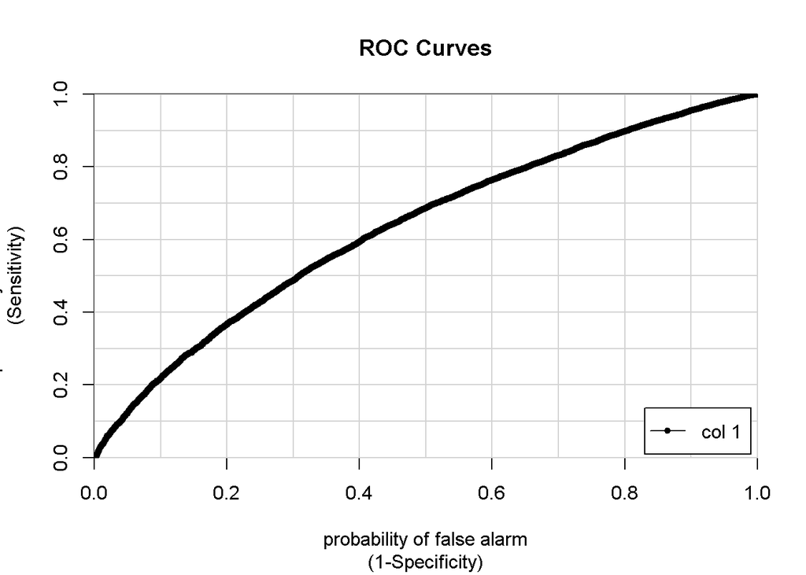

```
##              [,1]
## N vs. C 0.6316014
```

```r
# Draw a ROC curve
library(caTools)
colAUC(pII, testII$Class, plotROC = T)
```